# Lecture 17: Regression Continued

#Disregard the John Snow question on the practice. The data won’t work without doing some transformation that we haven’t discussed.

# Extra credit:

- A graduate student and faculty member in political science are doing a survey experiment. You can get extra credit equal to 1/2 point on your final grade if you take the survey and provide the information so they can report to me. (The survey results are separated out and kept anonymous.)
- Deadline is midnight Saturday.
- I have emailed this to everyone also.
- [survey](https://sewg.az1.qualtrics.com/jfe/form/SV_3V1S2RkXOf60rKm)

# Regression (Part 2)

- Review
- More on some terms that have been used occasionally: fit, fitted, predicted, residual, predictors, estimates (plus estimator and estimand)
- Regression with two or more Xs: multiple linear regression
- Review

$y = \alpha + \beta X + \epsilon$

- Assumptions

  ```
            + Linearity
            + Normality
            + Independence
            + Homoskedasticity
            + 7. No perfect multicollinearity
  ```

- The process of *least squared* residuals

  ```
            + Similar to the process of finding variance by measuring squared distances to the mean
            + This measures squared distances to the line given by the equation
            + The method aims to minimize the sum of the squared distances - the sum of squared residuals
  ```

$$\\[5in]$$

- New terms (new definitions)
- fit
- fitted
- predicted
- predictors
- estimates (plus estimator and estimand)
- residual - the vertical distance between the observed and the estimated (fitted, predicted) using estimated parameters.
- Multiple Linear Regression
- During the lecture on causation, I said that causes aren’t simple - there are often multiple causes
- So how do we analyze 2 (or 3 or 20) explanatory (X) variables

With OLS regression.

When we add a second X, we add a new axis so now we don’t have a line, we have the 3d equivalent::

$$\\[5in]$$

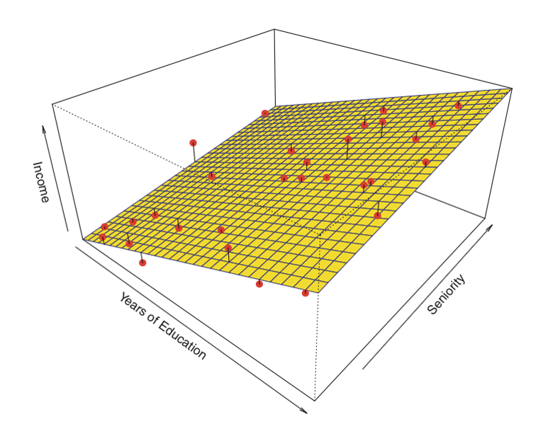

Multiple Regression plane

This is from one of the two best machine learning books out there and one that is available free from the authors:

[Introduction to Statistical Learning with Applications in R](https://www.statlearning.com/)

While it gets harder to graphically represent, from a practical perspective adding variables is just adding more elements to the equation:

$y = \alpha + \beta X + \epsilon$

BECOMES

$y = \alpha + \beta_1 X_1 + \beta_2 X_2 ... + \epsilon$

for as many Xes as we need.

$$\\[5in]$$

There is one big complication we have to avoid with multiple Xes:

Multicollinearity

Assumption #7 was “No perfect multicollinearity.”

What is multicollinearity?

If two Xes have a linear relationship and they both have a linear relationship with Y, the relationships are co-linear.

Multicollinearity just refers to any situation of two or more X variables with a relationship to Y and to each other. Perfect multicollinearity refers to the situation where two (or more) Xes have an exact linear relationship.

For example, if:

$X_1 = \alpha_2 + \beta_2 X_2 + \epsilon$

then we’d have a problem finding:

$y = \alpha + \beta_1 X_1 + \beta_2 X_2 + \epsilon$

Imagine a worst case where the two Xes are actually equal?